# FinalProjectBiology4415

Gavin Ieong

2023-09-26

## Part I: Different Visualization Techniques

We are doing this to make it easier to see changes compared to the stackerd bar graph in original paper. Helps aleviate the unlevelness and with a better colour scheme

```r
table10 <- as.data.frame(read_excel("table.XLSX", "Supplemental Table 10"))
```

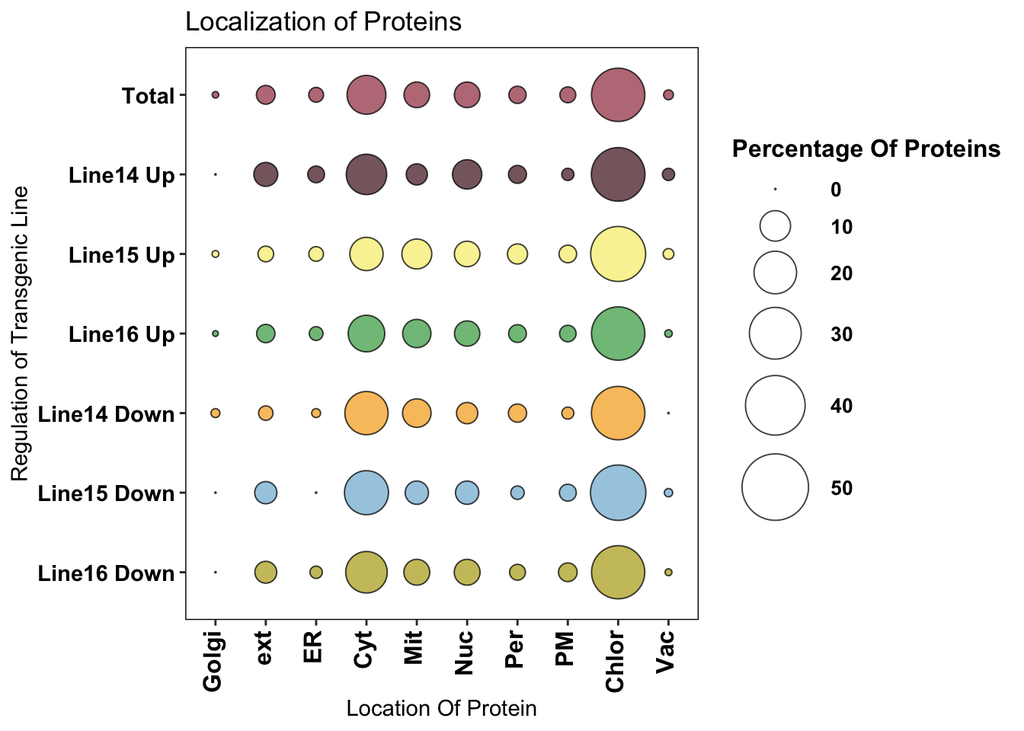

```r
colnames(table10) <- as.character(unlist(table10[1,]))
table10 <- table10[-1, ]

colnames(table10)[1] <- "Compartment"

bubbleProtein <- table10[, c(1,3,5,9,13,7,11,15)]

bubbleProtein[,(2:8) ] <- sapply(bubbleProtein[,(2:8) ] , as.numeric)
colnames(bubbleProtein) <- c("Compartment","Total","Line14 Up","Line15 Up","Line16 Up","Line14 Down","Line15 Down","Line16 Down")

bubbleProtein$Compartment <- factor(bubbleProtein$Compartment,levels=unique(bubbleProtein$Compartment))

bubbleProtein <- bubbleProtein[1:10,]
pcm = melt(bubbleProtein, id = c("Compartment"))
colours = c( "#A54657",  "#582630", "#F7EE7F", "#4DAA57",
           ## "#F1A66A","#F26157", "#F9ECCC", "#679289", "#33658A",
"#F6AE2D","#86BBD8","#B9AC2A") ##,"#C6BBD8""#8DFE2D")




ggplot(pcm, aes(x = Compartment, y = variable)) +
  geom_point(aes(size = value, fill = variable), alpha = 0.75, shape = 21) +
  scale_size_continuous(limits = c(0, 50), range = c(0,15), breaks = c(0,10, 20,30,40,50)) +
  labs( x= "Location Of Protein", y = "Regulation of Transgenic Line", title = "Localization of Proteins", size = "Percentage Of Proteins", fill = "")  +
  theme(legend.key=element_blank(),
  axis.text.x = element_text(colour = "black", size = 12, face = "bold", angle = 90, vjust = 0.3, hjust = 1),
  axis.text.y = element_text(colour = "black", face = "bold", size = 11),
  legend.text = element_text(size = 10, face ="bold", colour ="black"),
  legend.title = element_text(size = 12, face = "bold"),
  panel.background = element_blank(), panel.border = element_rect(colour = "black", fill = NA, size = .5),
  legend.position = "right") +
  scale_fill_manual(values = colours, guide = FALSE) +
  scale_y_discrete(limits = rev(levels(pcm$variable)))
```

```r
##ggsave("Protein_Bubble_Plot.png")
```

## Pca plot of protein intensities in each of the three transgenic lines, plus wild type replicates

Will produce PCA plot first, to confirm we have similar data compared to original paper

```r
table9 <- as.data.frame(read_excel("table.XLSX", "Supplemental Table 9"))
colnames(table9) <- as.character(unlist(table9[1,]))
table9 <- table9[-1, ]

table9[5:22] <- sapply(table9[5:22] , as.numeric)
```

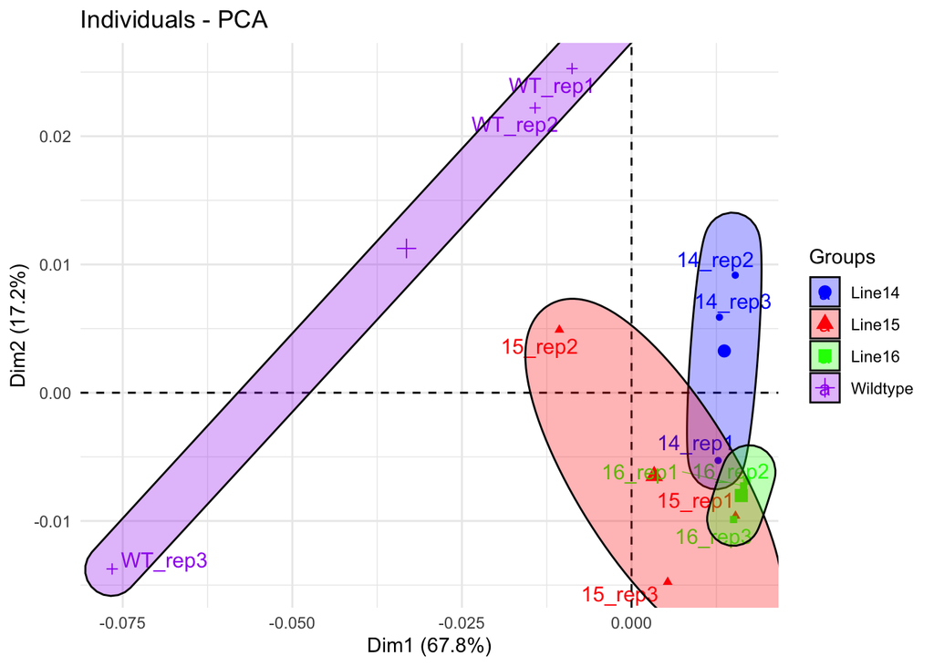

```r
allTrials <- table9[c(5:16)]
allTrials[allTrials==0] <- NA
allTrials<-allTrials[complete.cases(allTrials),]

data_normalized <- scale(allTrials)
corr_matrix <- cor(data_normalized)

## Can change col names after msking corr matrix to use as groups
colnames(allTrials)<- c("Wildtype","Wildtype","Wildtype","Line14","Line14","Line14","Line15","Line15","Line15","Line16","Line16","Line16")
data.pca <- princomp(corr_matrix)

group.colors <- c(Wildtype = "purple", Line14 = "blue", Line15 ="red", Line16 = "green")


fviz_pca_ind(data.pca,repel = T , habillage=colnames(allTrials)) +
  # ADD ggforce's ellipses
  ggforce::geom_mark_ellipse(aes(fill = Groups))  + theme_minimal()+scale_color_manual(values=group.colors)+scale_fill_manual(values=group.colors)
```

## Part II: Plot some basic information before looking at other graphs

Raw scatterplot of intensities compared to wildtype. Used as baseline, but will further use other plots to help confirm and find information.

```r
intensity <- as.data.frame(read_excel("table.XLSX", "AverageIntensity"))
intensity<- intensity[!duplicated(intensity$AGI), ]
rownames(intensity) <- intensity[,1]
intensity <- intensity[,-1]
intensity<- log10(intensity)

names(intensity)
```

```
## [1] "Average Intensity Of Wildtype Line" "Average Intensity Of  Line 14"
## [3] "Average Intensity Of  Line 15"      "Average Intensity Of Line 16"
```

```r
#intensity<-head(intensity,100)
par(mfrow=c(1,3))

ggscatter(intensity, x =  "Average Intensity Of Wildtype Line", y =  "Average Intensity Of  Line 14" ,
   add = "reg.line",  # Add regressin line
      color = "blue",
   add.params = list(color = "black", fill = "lightgray"), # Customize reg. line
   conf.int = TRUE # Add confidence interval
   )+ stat_cor(
   aes(label = paste(..rr.label.., sep = "~`,`~")),
  label.x = 3
)
```

[figure not shown]

```r
ggscatter(intensity, x =  "Average Intensity Of Wildtype Line", y =  "Average Intensity Of  Line 15" ,
   add = "reg.line",  # Add regressin line
   color = "red",
   add.params = list(color = "black", fill = "lightgray"), # Customize reg. line
   conf.int = TRUE # Add confidence interval
   )+ stat_cor(
   aes(label = paste(..rr.label.., sep = "~`,`~")),
  label.x = 3
)
```

[figure not shown]

```r
ggscatter(intensity, x =  "Average Intensity Of Wildtype Line", y =  "Average Intensity Of Line 16" ,
   add = "reg.line",  # Add regressin line
      color = "green",
   add.params = list(color = "black", fill = "lightgray"), # Customize reg. line
   conf.int = TRUE # Add confidence interval
   )+ stat_cor(
   aes(label = paste(..rr.label.., sep = "~`,`~")),
  label.x = 3
)
```

[figure not shown]

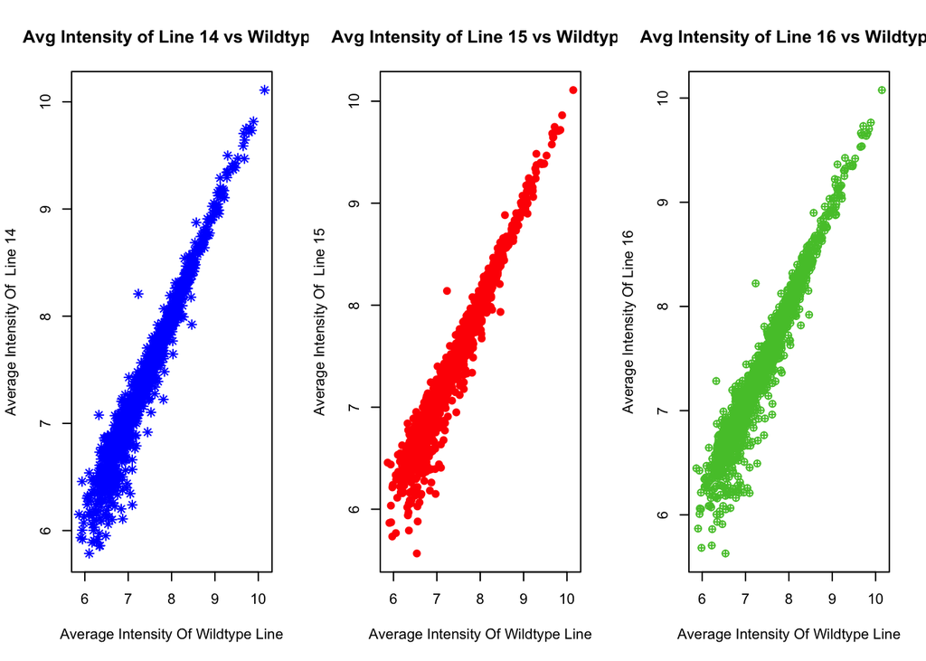

```r
plot(intensity[c(1,2)], col = "blue",pch = 8, main = "Avg Intensity of Line 14 vs Wildtype")

plot(intensity[c(1,3)], col = "red",pch = 19, main = "Avg Intensity of Line 15 vs Wildtype")

plot(intensity[c(1,4)], col = "#53C436",pch = 10, main = "Avg Intensity of Line 16 vs Wildtype")
```

## Visualize Foldchange of each lines using histogram

Distribution of log2 Fold Change in lines 14,15, 16 Line 15 and Line 16 seem to match more compared to Line 14, where more differences are noticed

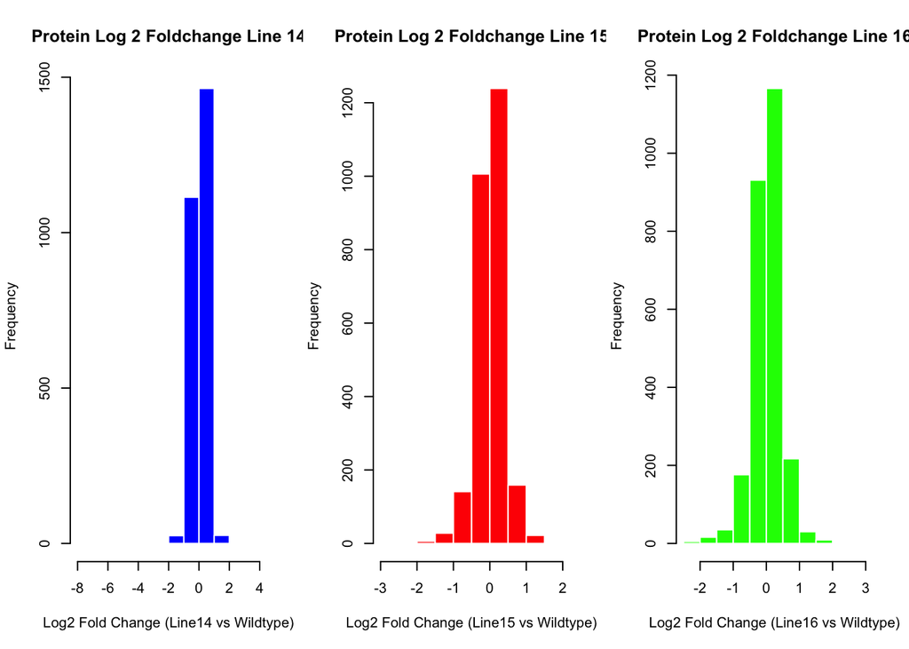

```r
topProteins <- as.data.frame(read_excel("table.XLSX", "TopGenes"))
par(mfrow=c(1,3))
hist(topProteins$FC_14_WT, xlab = "Log2 Fold Change (Line14 vs Wildtype)", main = "Protein Log 2 Foldchange Line 14",col = 'blue', border = "white")
hist(topProteins$FC_15_WT, xlab = "Log2 Fold Change (Line15 vs Wildtype)", main = "Protein Log 2 Foldchange Line 15",col = 'red', border = "white")
hist(topProteins$FC_16_WT, xlab = "Log2 Fold Change (Line16 vs Wildtype)", main = "Protein Log 2 Foldchange Line 16",col = 'green', border = "white")
```

## Heat map Of Log2Fold Change Against Wildtype

Once again, as seen from heatmap, line 14 shows most significant difference

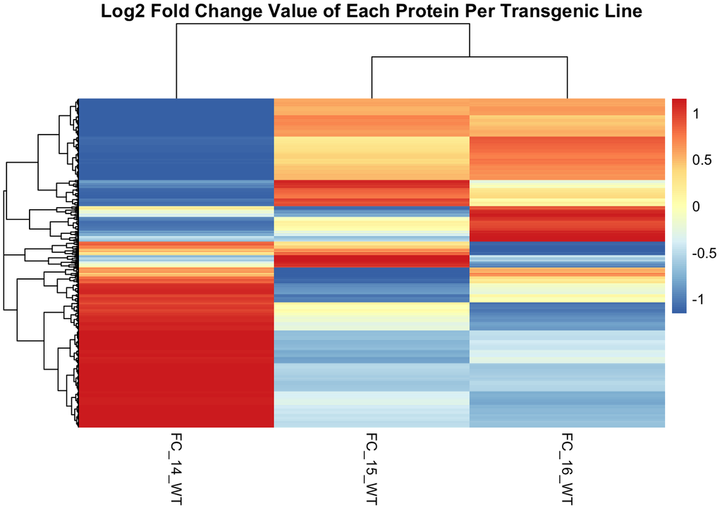

```r
myheatmap<- table9[c(4,20,21,22)]
myheatmap<-myheatmap[!duplicated(myheatmap$AGI),]
myheatmap <-na.omit(myheatmap)
pheatmap(as.matrix((myheatmap[2:4])), scale="row", show_rownames=F,legend = TRUE, main = "Log2 Fold Change Value of Each Protein Per Transgenic Line")
```

#### Citations

Used to get citations

```r
citation('pheatmap')
```

```
##
##
##   Kolde R (2019). _pheatmap: Pretty Heatmaps_. R package version
##   1.0.12, <https://CRAN.R-project.org/package=pheatmap>.
##
## A BibTeX entry for LaTeX users is
##
##   @Manual{,
##     title = {pheatmap: Pretty Heatmaps},
##     author = {Raivo Kolde},
##     year = {2019},
##     note = {R package version 1.0.12},
##     url = {https://CRAN.R-project.org/package=pheatmap},
##   }
##
## ATTENTION: This citation information has been auto-generated from the
## package DESCRIPTION file and may need manual editing, see
## 'help("citation")'.
```

```r
citation('ggplot2')
```

```
##
##
##   H. Wickham. ggplot2: Elegant Graphics for Data Analysis.
##   Springer-Verlag New York, 2016.
##
## A BibTeX entry for LaTeX users is
##
##   @Book{,
##     author = {Hadley Wickham},
##     title = {ggplot2: Elegant Graphics for Data Analysis},
##     publisher = {Springer-Verlag New York},
##     year = {2016},
##     isbn = {978-3-319-24277-4},
##     url = {https://ggplot2.tidyverse.org},
##   }
```

```r
citation('corrr')
```

```
##
##
##   Kuhn M, Jackson S, Cimentada J (2022). _corrr: Correlations in R_. R
##   package version 0.4.4, <https://CRAN.R-project.org/package=corrr>.
##
## A BibTeX entry for LaTeX users is
##
##   @Manual{,
##     title = {corrr: Correlations in R},
##     author = {Max Kuhn and Simon Jackson and Jorge Cimentada},
##     year = {2022},
##     note = {R package version 0.4.4},
##     url = {https://CRAN.R-project.org/package=corrr},
##   }
```

```r
citation('ggcorrplot')
```

```
##
##
##   Kassambara A (2022). _ggcorrplot: Visualization of a Correlation
##   Matrix using 'ggplot2'_. R package version 0.1.4,
##   <https://CRAN.R-project.org/package=ggcorrplot>.
##
## A BibTeX entry for LaTeX users is
##
##   @Manual{,
##     title = {ggcorrplot: Visualization of a Correlation Matrix using 'ggplot2'},
##     author = {Alboukadel Kassambara},
##     year = {2022},
##     note = {R package version 0.1.4},
##     url = {https://CRAN.R-project.org/package=ggcorrplot},
##   }
```

```r
citation('FactoMineR')
```

```
##
##
##   Sebastien Le, Julie Josse, Francois Husson (2008). FactoMineR: An R
##   Package for Multivariate Analysis. Journal of Statistical Software,
##   25(1), 1-18. 10.18637/jss.v025.i01
##
## A BibTeX entry for LaTeX users is
##
##   @Article{,
##     title = {{FactoMineR}: A Package for Multivariate Analysis},
##     author = {S\'ebastien L\^e and Julie Josse and Fran\c{c}ois Husson},
##     journal = {Journal of Statistical Software},
##     year = {2008},
##     volume = {25},
##     number = {1},
##     pages = {1--18},
##     doi = {10.18637/jss.v025.i01},
##   }
```

```r
citation('factoextra')
```

```
##
##
##   Kassambara A, Mundt F (2020). _factoextra: Extract and Visualize the
##   Results of Multivariate Data Analyses_. R package version 1.0.7.999,
##   <http://www.sthda.com/english/rpkgs/factoextra>.
##
## A BibTeX entry for LaTeX users is
##
##   @Manual{,
##     title = {factoextra: Extract and Visualize the Results of Multivariate Data Analyses},
##     author = {Alboukadel Kassambara and Fabian Mundt},
##     year = {2020},
##     note = {R package version 1.0.7.999},
##     url = {http://www.sthda.com/english/rpkgs/factoextra},
##   }
```

```r
citation('ggfortify')
```

```
##
##
##   Yuan Tang, Masaaki Horikoshi, and Wenxuan Li. "ggfortify: Unified
##   Interface to Visualize Statistical Result of Popular R Packages." The
##   R Journal 8.2 (2016): 478-489.
##
##   Masaaki Horikoshi and Yuan Tang (2016). ggfortify: Data Visualization
##   Tools for Statistical Analysis Results.
##   https://CRAN.R-project.org/package=ggfortify
##
## To see these entries in BibTeX format, use 'print(<citation>,
## bibtex=TRUE)', 'toBibtex(.)', or set
## 'options(citation.bibtex.max=999)'.
```

```r
citation('ggpubr')
```

```
##
##
##   Kassambara A (2023). _ggpubr: 'ggplot2' Based Publication Ready
##   Plots_. R package version 0.6.0,
##   <https://CRAN.R-project.org/package=ggpubr>.
##
## A BibTeX entry for LaTeX users is
##
##   @Manual{,
##     title = {ggpubr: 'ggplot2' Based Publication Ready Plots},
##     author = {Alboukadel Kassambara},
##     year = {2023},
##     note = {R package version 0.6.0},
##     url = {https://CRAN.R-project.org/package=ggpubr},
##   }
```

#### Bubble Plot (Gene Count) This section removed, as no need to do genes when working with proteomics.

```r
table1 <- as.data.frame(read_excel("table.XLSX", "Supplemental Table 1"))
colnames(table1) <- as.character(unlist(table1[1,]))
table1 <- table1[-1, ]
#rownames(table1)<- table1[,1]
#table1<- table1[,-1]
table1[,(2:15) ] <- sapply(table1[,(2:15) ] , as.numeric)

bubblePlotGene <- table1[c(1,3,5,7,9,11,13,15)]
colnames(bubblePlotGene) <- c("Compartment","Total","Line14 Up","Line15 Up","Line16 Up","Line14 Down","Line15 Down","Line16 Down")

pcm = melt(bubblePlotGene, id = c("Compartment"))

colours = c( "#A54657",  "#582630", "#F7EE7F", "#4DAA57",
           ## "#F1A66A","#F26157", "#F9ECCC", "#679289", "#33658A",
"#F6AE2D","#86BBD8","#B9AC2A") ##,"#C6BBD8""#8DFE2D")

bubblePlotGene$Compartment <- factor(bubblePlotGene$Compartment,levels=unique(table$bubblePlotGene))


ggplot(pcm, aes(x = Compartment, y = variable)) +
  geom_point(aes(size = value, fill = variable), alpha = 0.75, shape = 21) +
  scale_size_continuous(limits = c(0, 100), range = c(0,10), breaks = c(0,20, 40, 60, 80, 100)) +
  labs( x= "Location Of Gene", y = "Regulation of Transgenic Line", title = "Localization of Genes", size = "Gene Count Percentage", fill = "")  +
  theme(legend.key=element_blank(),
  axis.text.x = element_text(colour = "black", size = 12, face = "bold", angle = 90, vjust = 0.3, hjust = 1),
  axis.text.y = element_text(colour = "black", face = "bold", size = 11),
  legend.text = element_text(size = 10, face ="bold", colour ="black"),
  legend.title = element_text(size = 12, face = "bold"),
  panel.background = element_blank(), panel.border = element_rect(colour = "black", fill = NA, size = .5),
  legend.position = "right") +
  scale_fill_manual(values = colours, guide = FALSE) +
  scale_y_discrete(limits = rev(levels(pcm$variable)))
```

##### This section removed from final analysis, but kept code in, incase of using later

Creating venn diagram of same and different proteins and genes

```r
topProteins <- as.data.frame(read_excel("table.XLSX", "TopGenes"))

l14 <- topProteins[c(3,4)] %>% na.omit()
l15 <- topProteins[c(5,6)]%>% na.omit()
l16 <- topProteins[c(7,8)]%>% na.omit()


class(l14)
list1 <- as.list.data.frame(l14)
list1$`AGI 14`
#ggvenn(x, show_elements = T, label_sep = "\n", fill_color = brewer.pal(name="Set2",n=3))
#venn.diagram(x=list(l14$`AGI 14`, l15$`AGI 15`, l16$`AGI 16`),
#              label=TRUE,
#             category.names = c("Line 14" , "Line 15" , "Line 16"),
#           filename = 'venn',
#              output=TRUE,
#               lwd = 3,
#                lty = 'blank',
#              ## sets the color from brewer package
#                fill =  brewer.pal(3, "Set3"))
knitr::include_graphics("/Users/gavin/Desktop/Biology4415Labs/venn.png")
```